# Discrete Probability

Raúl López

2024-02-26

The probability of an event is the proportion of times the event occurs when we repeat the experiment independently under the same conditions.

An event is defined as an outcome that can occur when when something happens by chance.

For example, if we have an urn with 8 red, 2 green and 6 orange balls, the probability of drawing a red ball is 8/(8+2+6).

```r
cyan <- 3
magenta <- 5
yellow <- 7

p <- cyan/(cyan+magenta+yellow) # probability of getting a cyan ball
p
```

```
## [1] 0.2
```

```r
1 - p # probability of not getting a cyan ball
```

```
## [1] 0.8
```

## Monte Carlo simulations

Monte Carlo simulations model the probability of different outcomes by repeating a random process a large enough number of times that the results are similar to what would be observed if the process were repeated forever.

The `sample()` function draws random outcomes from a set of options. `The replicate()` function repeats lines of code a set number of times. It is used with `sample()` and similar functions to run Monte Carlo simulations.

```r
beads <- rep(c("red", "blue"), times = c(2,3))    # create an urn with 2 red, 3 blue
beads    # view beads object
```

```
## [1] "red"  "red"  "blue" "blue" "blue"
```

```r
sample(beads, 1)    # sample 1 bead at random
```

```
## [1] "blue"
```

```r
B <- 10000    # number of times to draw 1 bead
events <- replicate(B, sample(beads, 1))    # draw 1 bead, B times
tab <- table(events)    # make a table of outcome counts
tab    # view count table
```

```
## events
## blue  red
## 6059 3941
```

```r
prop.table(tab)    # view table of outcome proportions
```

```
## events
##   blue    red
## 0.6059 0.3941
```

We can use the `mean()` function in order to calculate the probability of a Monte Carlo simulation

```r
mean(events == "red")
```

```
## [1] 0.3941
```

# Independence

Conditional probabilities compute the probability that an event occurs given information about dependent events. For example, the probability of drawing a second king given that the first draw is a king is:

```r
n <- 52 # number of cards
pking1 <- 4/52 # probability of drawing a king
n <- 52 - 1 # we do not replace the king card
pking2 <- 3/51 # probability of drawing a second king
```

On the other hand, when we have two independent events, the probabilities of each one is not affected by the other.

To determine the probability of multiple events occurring, we use the multiplication rule.

```r
pking1 * pking2 # Probabiliy of drawing two kings by row
```

```
## [1] 0.004524887
```

The multiplication rule also gives us a general formula for computing conditional probabilities:

Probability of B when A occurs is the probability of two events divided by the probability of A

Pr(B | A) = (P(A) & P(b)) / P(A)

## Exercises

1. If you roll a 6-sided die once, what is the probability of not seeing a 6? If you roll a 6-sided die six times, what is the probability of not seeing a 6 on any of those rolls?

```r
p <- 5/6 # probability of not seeing a 6
p^6 # probability of not seeing a 6 in 6 rolls
```

```
## [1] 0.334898
```

2. Two teams, say the Celtics and the Cavs, are playing a seven game series. The Cavs are a better team and have a 60% chance of winning each game. What is the probability that the Celtics win at least one game?

```r
celtics_win_all <- 0.6^4 # probability that celtics win 4 games
1 - celtics_win_all # probability that Cavs win at least 1 game
```

```
## [1] 0.8704
```

3. Create a Monte Carlo simulation to confirm your answer to the previous problem by estimating how frequently the Celtics win at least 1 of 4 games. Use B <- 10000 simulations.

```r
B <- 10000
celtic_wins <- replicate(B, {
  simulated_games <- sample(c("lose","win"), 4, replace = TRUE, prob = c(0.6, 0.4))
  any(simulated_games=="win")
})

# Calculate the frequency out of B iterations that the Celtics won at least one game. Print your answer to the console.
mean(celtic_wins)
```

```
## [1] 0.8669
```

# Combination and Permutations

`paste()` joins two strings and inserts a space in between.

```r
number <- "Three"
suit <- "Hearts"
paste(number, suit)
```

```
## [1] "Three Hearts"
```

`expand.grid()` gives the combinations of 2 vectors or lists.

```r
expand.grid(pants = c("blue", "black"), shirt = c("white", "grey", "pink"))
```

```
##   pants shirt
## 1  blue white
## 2 black white
## 3  blue  grey
## 4 black  grey
## 5  blue  pink
## 6 black  pink
```

`permutations(n,r)` from the gtools package lists the different ways that r items can be selected from a set of n options when order matters.

```r
# Generating the deck of cards
suits <- c("Diamonds", "Clubs", "Hearts", "Spades")
numbers <- c("Ace", "Deuce", "Three", "Four", "Five", "Six", "Seven", "Eight", "Nine", "Ten", "Jack", "Queen", "King")
deck <- expand.grid(number = numbers, suit = suits)
deck <- paste(deck$number, deck$suit)
head(deck)
```

```
## [1] "Ace Diamonds"   "Deuce Diamonds" "Three Diamonds" "Four Diamonds"
## [5] "Five Diamonds"  "Six Diamonds"
```

```r
library(gtools)

hands <- permutations(52,2, v = deck)
dim(hands)
```

```
## [1] 2652    2
```

```r
summary(hands)
```

```
##       V1                 V2
##  Length:2652        Length:2652
##  Class :character   Class :character
##  Mode  :character   Mode  :character
```

We can now calculate the probability of drawing a second king given that one king is drawn as:

```r
kings <- paste("King", suits)
first_card <- hands[,1]
second_card <- hands[,2]
sum(first_card %in% kings) # Number of permutations in which first card is a king
```

```
## [1] 204
```

```r
sum(first_card %in% kings & second_card %in% kings) # number of permutation in which first and second cards are a king
```

```
## [1] 12
```

```r
sum(first_card %in% kings & second_card %in% kings) / sum(first_card %in% kings) # the probability of getting two kings in a row
```

```
## [1] 0.05882353
```

`combinations(n,r)` from the gtools package lists the different ways that r items can be selected from a set of n options when order does not matter.

```r
hands <- combinations(52, 2, v=deck)
dim(hands)
```

```
## [1] 1326    2
```

```r
summary(hands)
```

```
##       V1                 V2
##  Length:1326        Length:1326
##  Class :character   Class :character
##  Mode  :character   Mode  :character
```

Now we can compute the probability of a natural 21 in blackjack (getting an Ace and a facecard; the order does not matter)

```r
aces <- paste("Ace", suits)
facecard <- c("King", "Queen", "Jack", "Ten")
facecard <- expand.grid(number = facecard, suit = suits)
facecard <- paste(facecard$number, facecard$suit)

hands <- combinations(52, 2, v=deck) # all possible hands

# probability of a natural 21 checking for both ace first and ace second
mean((hands[,1] %in% aces & hands[,2] %in% facecard)|(hands[,2] %in% aces & hands[,1] %in% facecard))
```

```
## [1] 0.04826546
```

# Birthday Problem

Suppose you are in a classroom with 50 people. If we assume this is a randomly selected group of 50 people, what is the chance that at least two people have the same birthday? Although it is somewhat advanced, we can deduce this mathematically. We will do this later. Here we use a Monte Carlo simulation. For simplicity, we assume nobody was born on February 29. This actually doesn’t change the answer much.

First, note that birthdays can be represented as numbers between 1 and 365, so a sample of 50 birthdays can be obtained like this:

```r
n <- 50
bdays <- sample(1:365, n, replace = TRUE)
any(duplicated(bdays)) # check for any duplicated birthday
```

```
## [1] TRUE
```

To estimate the probability of a shared birthday in the group, we repeat this experiment by sampling sets of 50 birthdays over and over

```r
B <- 10000
same_birthday <- function(n){
  bdays <- sample(1:365, n, replace=TRUE)
  any(duplicated(bdays))
}
results <- replicate(B, same_birthday(50))
mean(results)
```

```
## [1] 0.9703
```

Say we want to use this knowledge to bet with friends about two people having the same birthday in a group of people. When are the chances larger than 50%? Larger than 75%?

```r
compute_prob <- function(n, B=10000){
  results <- replicate(B, same_birthday(n)) # compute probs for all sample size
  mean(results)
}
n <- seq(1,60)
prob <- sapply(n, compute_prob)
library(tidyverse)
```

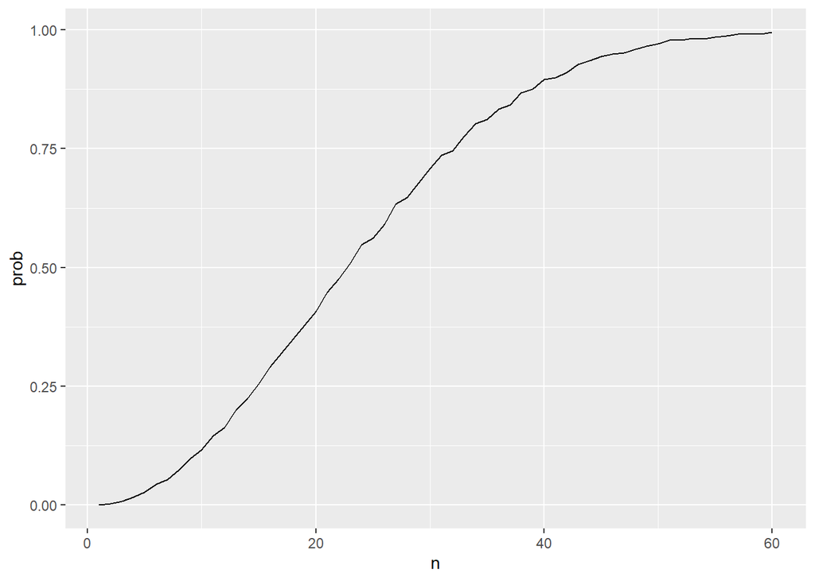

```r
df <- data.frame(prob = prob, n = n)
ggplot(df, aes(x = n, y = prob))+
  geom_line()
```

Now let’s compute the exact probabilities rather than use Monte Carlo approximations. Not only do we get the exact answer using math, but the computations are much faster since we don’t have to generate experiments.

To make the math simpler, instead of computing the probability of it happening, we will compute the probability of it not happening. For this, we use the multiplication rule.

Let’s start with the first person. The probability that person 1 has a unique birthday is 1. The probability that person 2 has a unique birthday, given that person 1 already took one, is 364/365. Then, given that the first two people have unique birthdays, person 3 is left with 363 days to choose from.

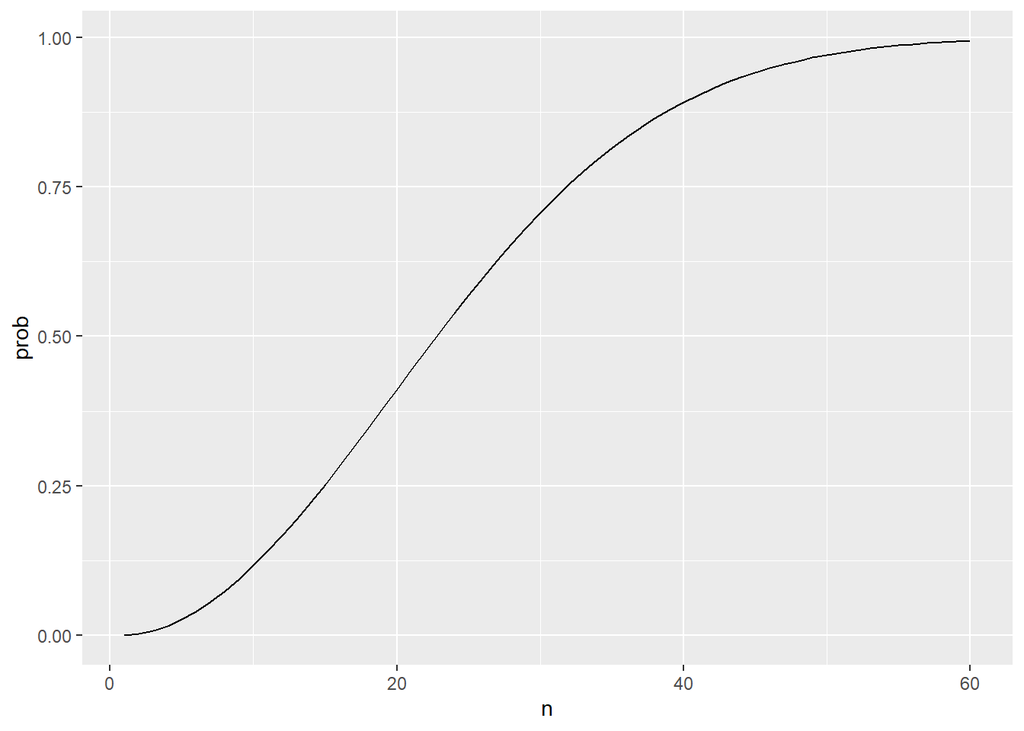

```r
for (i in 1:50){
  p <- (365 - n + 1)/365 # probability of having unique birthdays
}

# in other words
exact_prob <- function(n){
  prob_unique <- seq(365,365-n+1)/365 # probability of having unique birthday
  1 - prod( prob_unique) # prod is the multiplication of vector
}

eprob <- sapply(n, exact_prob)

df <- data.frame(prob = eprob, n = n)
ggplot(df, aes(x = n, y = prob))+
  geom_line()
```

# How Many Monte Carlo Experiments are Enough?

The larger the number of Monte Carlo replicates (B) , the more accurate the estimate.

Determining the appropriate size for can require advanced statistics.

One practical approach is to try many sizes for and look for sizes that provide stable estimates.

This code runs Monte Carlo simulations to estimate the probability of shared birthdays using several B values and plots the results. When B is large enough that the estimated probability stays stable, then we have selected a useful value of B.

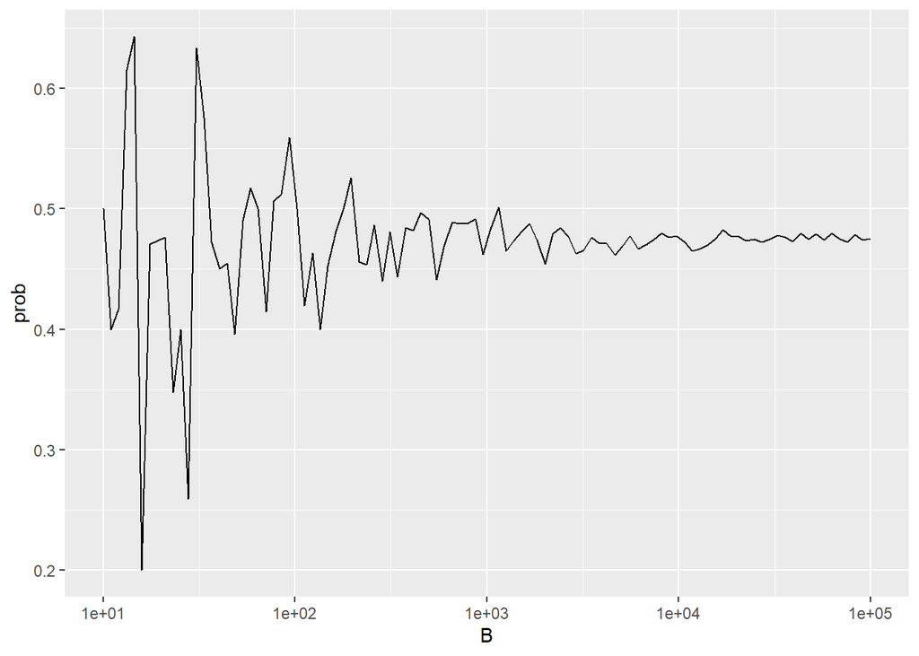

```r
B <- 10^seq(1, 5, len = 100)    # defines vector of many B values
compute_prob <- function(B, n = 22){    # function to run Monte Carlo simulation with each B
    same_day <- replicate(B, {
        bdays <- sample(1:365, n, replace = TRUE)
      any(duplicated(bdays))
    })
    mean(same_day)
}

prob <- sapply(B, compute_prob)    # apply compute_prob to many values of B
df <- data.frame(prob = prob, B = B)
ggplot(df, aes(x = B, y = prob))+
  geom_line()+
  scale_x_log10()
```

# Exercises

1. Two teams, say the Cavs and the Warriors, are playing a seven game championship series. The first to win four games wins the series. The teams are equally good, so they each have a 50-50 chance of winning each game. If the Cavs lose the first game, what is the probability that they win the series?

```r
n <- 6 # remaining games (7 - 1)
outcomes <- c(0,1)  # possible results where 0 indicates a loss and 1 indicates a win for the Cavs
l<-rep(list(outcomes),n) # list of all possible outcomes in all remaining games
possibilities<-expand.grid(l) # data frame containing all the combinations
results <- rowSums(possibilities) >= 4 # which combinations of game outcomes result in the Cavs winning 4 or more games
mean(results) # compute probability
```

```
## [1] 0.34375
```

2. Confirm the results of the previous question with a Monte Carlo simulation to estimate the probability of the Cavs winning the series after losing the first game.

```r
B <- 10000
set.seed(1)
results <- replicate(B, {
  x <- sample(c(0,1), 6, replace = TRUE)
  sum(x) >= 4
})
mean(results)
```

```
## [1] 0.3371
```

3. Two teams, A and B, are playing a seven series game series. Team A is better than team B and has a p > 0.5 chance of winning each game.

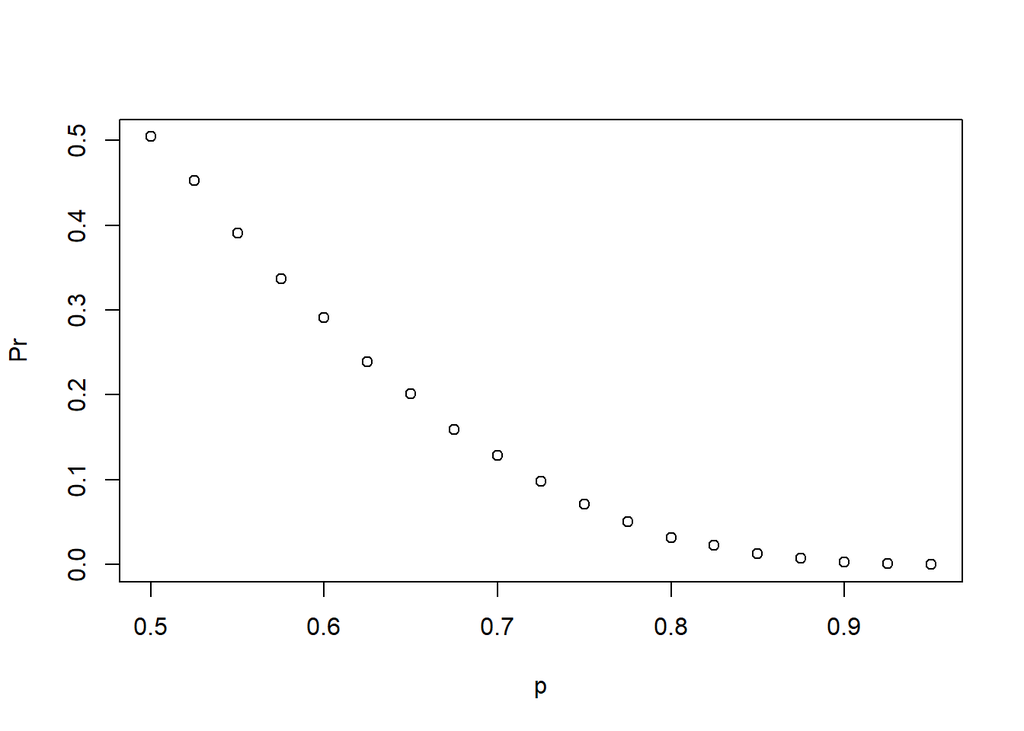

```r
p <- seq(0.5, 0.95, 0.025)
prob_win <- function(p){
  B <- 10000
  results <- replicate(B, {
    b_win <- sample(c(1,0), 7, replace = T, prob = c(1-p, p))
    sum(b_win) >= 4
  })
  mean(results)
}

Pr <- sapply(p, prob_win)
plot(p, Pr)
```

4. Repeat the previous exercise, but now keep the probability that team A wins fixed at p <- 0.75 and compute the probability for different series lengths. For example, wins in best of 1 game, 3 games, 5 games, and so on through a series that lasts 25 games.

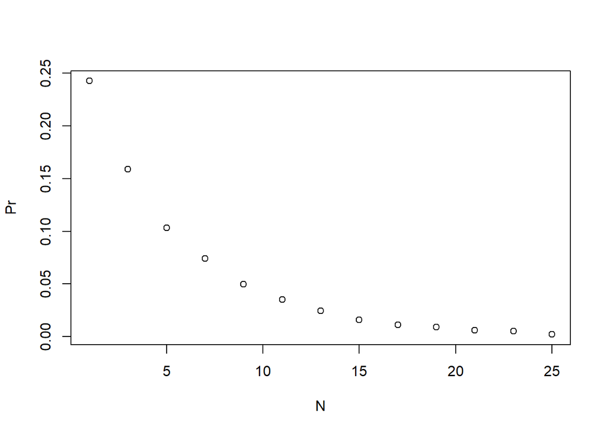

```r
prob_win <- function(N, p=0.75){
  B <- 10000
  result <- replicate(B, {
    b_win <- sample(c(1,0), N, replace = TRUE, prob = c(1-p, p))
    sum(b_win)>=(N+1)/2
  })
  mean(result)
}

N <- seq(1,25,2)

Pr <- sapply(N, prob_win)
plot(N, Pr)
```

# Addition Rule

The addition rule states that the probability of event A or event B happening is the probability of event A plus the probability of event B minus the probability of both events and happening together.

The addition rule for a natural 21 in blackjack

We apply the addition rule where A = drawing an ace then a facecard and B = drawing a facecard then an ace. Note that in this case, both events A and B cannot happen at the same time, so Pr(A and B) = 0.

```r
p_ace_and_facecard <- (4/52) * (16/51)
p_facecard_and_ace <- (16/52) * (4/51)

p_one_or_other <- p_ace_and_facecard + p_facecard_and_ace - 0
p_one_or_other
```

```
## [1] 0.04826546
```

# Monty Hall Problem

Monte Carlo simulations can be used to simulate random outcomes, which makes them useful when exploring ambiguous or less intuitive problems like the Monty Hall problem.

In the Monty Hall problem, contestants choose one of three doors that may contain a prize. Then, one of the doors that was not chosen by the contestant and does not contain a prize is revealed. The contestant can then choose whether to stick with the original choice or switch to the remaining unopened door.

Although it may seem intuitively like the contestant has a 1 in 2 chance of winning regardless of whether they stick or switch, Monte Carlo simulations demonstrate that the actual probability of winning is 1 in 3 with the stick strategy and 2 in 3 with the switch strategy.

```r
# Monte Carlo simulation of stick strategy
B <- 10000
stick <- replicate(B, {
    doors <- as.character(1:3)
    prize <- sample(c("car","goat","goat"))    # puts prizes in random order
    prize_door <- doors[prize == "car"]    # note which door has prize
    my_pick  <- sample(doors, 1)    # note which door is chosen
    show <- sample(doors[!doors %in% c(my_pick, prize_door)],1)    # open door with no prize that isn't chosen
    stick <- my_pick    # stick with original door
    stick == prize_door    # test whether the original door has the prize
})
mean(stick)    # probability of choosing prize door when sticking
```

```
## [1] 0.3372
```

```r
# Monte Carlo simulation of switch strategy
switch <- replicate(B, {
    doors <- as.character(1:3)
    prize <- sample(c("car","goat","goat"))    # puts prizes in random order
    prize_door <- doors[prize == "car"]    # note which door has prize
    my_pick  <- sample(doors, 1)    # note which door is chosen first
    show <- sample(doors[!doors %in% c(my_pick, prize_door)], 1)    # open door with no prize that isn't chosen
    switch <- doors[!doors%in%c(my_pick, show)]    # switch to the door that wasn't chosen first or opened
    switch == prize_door    # test whether the switched door has the prize
})
mean(switch)    # probability of choosing prize door when switching
```

```
## [1] 0.6688
```

# Olympic Running

In the 200m dash finals in the Olympics, 8 runners compete for 3 medals (order matters). In the 2012 Olympics, 3 of the 8 runners were from Jamaica and the other 5 were from different countries. The three medals were all won by Jamaica (Usain Bolt, Yohan Blake, and Warren Weir).

1. How many different ways can the 3 medals be distributed across 8 runners?

```r
medals <- c("Gold", "Silver", "Bronze")
runners <- paste0("Runner",seq(1,8))
ways <- expand.grid(runner = runners, medal = medals)
ways <- paste(ways$runner, ways$medal)
winners <- permutations(8, 3, v=ways)
nrow(winners)
```

```
## [1] 336
```

2. How many different ways can the three medals be distributed among the 3 runners from Jamaica?

```r
medals <- c("Gold", "Silver", "Bronze")
runners <- paste0("Runner",seq(1,3))
ways <- expand.grid(runner = runners, medal = medals)
ways <- paste(ways$runner, ways$medal)
winners <- permutations(3, 3, v=ways)
nrow(winners)
```

```
## [1] 6
```

3. What is the probability that all 3 medals are won by Jamaica?

```r
# first we applied a monte carlo simulation
B <- 10000
jam_wins <- replicate(B, {
  jam_runners <- c(1,2,3)
  winners <- sample(seq(1,8), 3, replace = FALSE)
  all(winners %in% jam_runners)
})
mean(jam_wins)
```

```
## [1] 0.0192
```

```r
# calculate the probability
pgold <- 3/8 # probability of winning a gold
psilver <- 2/7 # probability of winning a silver
pbronze <- 1/6 # probability of winning a bronze

pgold * psilver * pbronze
```

```
## [1] 0.01785714
```

4. Run a Monte Carlo simulation on this vector representing the countries of the 8 runners in this race:

```r
runners <- c("Jamaica", "Jamaica", "Jamaica", "USA", "Ecuador", "Netherlands", "France", "South Africa")
B <- 10000
set.seed(1)
jam_wins <- replicate(B, {
  winners <- sample(runners, 3, replace = FALSE)
  all(winners == "Jamaica")
})
mean(jam_wins)
```

```
## [1] 0.0174
```

# Restaurant Management

A restaurant manager wants to advertise that his lunch special offers enough choices to eat different meals every day of the year. He doesn’t think his current special actually allows that number of choices, but wants to change his special if needed to allow at least 365 choices.

A meal at the restaurant includes 1 entree, 2 sides, and 1 drink. He currently offers a choice of 1 entree from a list of 6 options, a choice of 2 different sides from a list of 6 options, and a choice of 1 drink from a list of 2 options.

1. How many meal combinations are possible with the current menu?

```r
# Different meals = 6
# Different sides = 15
combinations(6,2)
```

```
##       [,1] [,2]
##  [1,]    1    2
##  [2,]    1    3
##  [3,]    1    4
##  [4,]    1    5
##  [5,]    1    6
##  [6,]    2    3
##  [7,]    2    4
##  [8,]    2    5
##  [9,]    2    6
## [10,]    3    4
## [11,]    3    5
## [12,]    3    6
## [13,]    4    5
## [14,]    4    6
## [15,]    5    6
```

```r
# Different drink = 2
6*15*2
```

```
## [1] 180
```

2. The manager has one additional drink he could add to the special. How many combinations are possible if he expands his original special to 3 drink options?

```r
6*15*3
```

```
## [1] 270
```

3. The manager decides to add the third drink but needs to expand the number of options. The manager would prefer not to change his menu further and wants to know if he can meet his goal by letting customers choose more sides. How many meal combinations are there if customers can choose from 6 entrees, 3 drinks, and select 3 sides from the current 6 options?

```r
# Different meals = 6
# Different sides = 20
combinations(6,3)
```

```
##       [,1] [,2] [,3]
##  [1,]    1    2    3
##  [2,]    1    2    4
##  [3,]    1    2    5
##  [4,]    1    2    6
##  [5,]    1    3    4
##  [6,]    1    3    5
##  [7,]    1    3    6
##  [8,]    1    4    5
##  [9,]    1    4    6
## [10,]    1    5    6
## [11,]    2    3    4
## [12,]    2    3    5
## [13,]    2    3    6
## [14,]    2    4    5
## [15,]    2    4    6
## [16,]    2    5    6
## [17,]    3    4    5
## [18,]    3    4    6
## [19,]    3    5    6
## [20,]    4    5    6
```

```r
# Different drink = 3
6*20*3
```

```
## [1] 360
```

4. The manager is concerned that customers may not want 3 sides with their meal. He is willing to increase the number of entree choices instead, but if he adds too many expensive options it could eat into profits. He wants to know how many entree choices he would have to offer in order to meet his goal.
- Write a function that takes a number of entree choices and returns the number of meal combinations possible given that number of entree options, 3 drink choices, and a selection of 2 sides from 6 options.
- Use sapply() to apply the function to entree option counts ranging from 1 to 12.

What is the minimum number of entree options required in order to generate more than 365 combinations?

```r
meal_combs <- function(n){
  drinks <- 3
  sides <- 15
  n*drinks*sides
}

sapply(1:12, meal_combs)
```

```
##  [1]  45  90 135 180 225 270 315 360 405 450 495 540
```

5. The manager isn’t sure he can afford to put that many entree choices on the lunch menu and thinks it would be cheaper for him to expand the number of sides. He wants to know how many sides he would have to offer to meet his goal of at least 365 combinations.
- Write a function that takes a number of side choices and returns the number of meal combinations possible given 6 entree choices, 3 drink choices, and a selection of 2 sides from the specified number of side choices.
- Use sapply() to apply the function to side counts ranging from 2 to 12.

What is the minimum number of side options required in order to generate more than 365 combinations?

```r
meal_combs <- function(n){
  drinks <- 3
  entrees <- 6
  sides <- nrow(combinations(n,2))
  drinks*entrees*sides
}

sapply(2:12, meal_combs)
```

```
##  [1]   18   54  108  180  270  378  504  648  810  990 1188
```

# Esophageal cancer and alcohol/tobacco use

Case-control studies help determine whether certain exposures are associated with outcomes such as developing cancer. The built-in dataset esoph contains data from a case-control study in France comparing people with esophageal cancer (cases, counted in ncases) to people without esophageal cancer (controls, counted in ncontrols) that are carefully matched on a variety of demographic and medical characteristics. The study compares alcohol intake in grams per day (alcgp) and tobacco intake in grams per day (tobgp) across cases and controls grouped by age range (agegp).

```r
head(esoph)
```

```
##   agegp     alcgp    tobgp ncases ncontrols
## 1 25-34 0-39g/day 0-9g/day      0        40
## 2 25-34 0-39g/day    10-19      0        10
## 3 25-34 0-39g/day    20-29      0         6
## 4 25-34 0-39g/day      30+      0         5
## 5 25-34     40-79 0-9g/day      0        27
## 6 25-34     40-79    10-19      0         7
```

Each row contains one group of the experiment. Each group has a different combination of age, alcohol consumption, and tobacco consumption. The number of cancer cases and number of controls (individuals without cancer) are reported for each group.

1. How many groups are in the study?

```r
nrow(esoph)
```

```
## [1] 88
```

2. How many cases are there? How many controls are there?

```r
all_cases <- sum(esoph$ncases)
all_cases
```

```
## [1] 200
```

```r
all_controls <- sum(esoph$ncontrols)
all_controls
```

```
## [1] 775
```

3. What is the probability that a subject in the highest alcohol consumption group is a cancer case?

```r
esoph %>% filter(alcgp == "120+") %>%
  summarize(sum_cases=sum(ncases), tot=sum(ncontrols) + sum(ncases), probability=sum_cases/tot)
```

```
##   sum_cases tot probability
## 1        45  67   0.6716418
```

4. What is the probability that a subject in the lowest alcohol consumption group is a cancer case?

```r
esoph %>% filter(alcgp == "0-39g/day") %>%
  summarize(sum_cases=sum(ncases), tot=sum(ncontrols)+sum(ncases), probability=sum_cases/tot)
```

```
##   sum_cases tot probability
## 1        29 415  0.06987952
```

5. Given that a person is a case, what is the probability that they smoke 10g or more a day?

```r
esoph %>% summarize(tot_cases = sum(ncases))
```

```
##   tot_cases
## 1       200
```

```r
esoph %>% filter(tobgp != "0-9g/day") %>%
  summarize(smoking10_cases = sum(ncases))
```

```
##   smoking10_cases
## 1             122
```

```r
122/200
```

```
## [1] 0.61
```

6. Given that a person is a control, what is the probability that they smoke 10g or more a day

```r
esoph %>% summarize(tot_control = sum(ncontrols)) %>% pull(tot_control)
```

```
## [1] 775
```

```r
esoph %>% filter(tobgp != "0-9g/day") %>%
  summarize(smoking10_controls = sum(ncontrols)) %>% pull(smoking10_controls)
```

```
## [1] 328
```

```r
328/775
```

```
## [1] 0.4232258
```

7. For cases, what is the probability of being in the highest alcohol group?

```r
esoph %>% summarize(tot_cases = sum(ncases)) %>% pull(tot_cases)
```

```
## [1] 200
```

```r
esoph %>% filter(alcgp == "120+") %>%
  summarize(highest_alc = sum(ncases)) %>% pull(highest_alc)
```

```
## [1] 45
```

```r
45/200
```

```
## [1] 0.225
```

8. For cases, what is the probability of being in the highest tobacco group?

```r
esoph %>% summarize(tot_cases = sum(ncases)) %>% pull(tot_cases)
```

```
## [1] 200
```

```r
esoph %>% filter(tobgp == "30+") %>%
  summarize(highest_tob = sum(ncases)) %>% pull(highest_tob)
```

```
## [1] 31
```

```r
31/200
```

```
## [1] 0.155
```

9. For cases, what is the probability of being in the highest alcohol group and the highest tobacco group?

```r
esoph %>% summarize(tot_cases = sum(ncases)) %>% pull(tot_cases)
```

```
## [1] 200
```

```r
esoph %>% filter(tobgp == "30+", alcgp == "120+") %>%
  summarize(highest_tob = sum(ncases)) %>% pull(highest_tob)
```

```
## [1] 10
```

```r
10/200
```

```
## [1] 0.05
```

10. For cases, what is the probability of being in the highest alcohol group or the highest tobacco group?

```r
esoph %>% summarize(tot_cases = sum(ncases)) %>% pull(tot_cases)
```

```
## [1] 200
```

```r
esoph %>% filter(tobgp == "30+" | alcgp == "120+") %>%
  summarize(highest_tob = sum(ncases)) %>% pull(highest_tob)
```

```
## [1] 66
```

```r
66/200
```

```
## [1] 0.33
```

11. For controls, what is the probability of being in the highest alcohol group?

```r
esoph %>% summarize(tot_cntrls = sum(ncontrols)) %>% pull(tot_cntrls)
```

```
## [1] 775
```

```r
esoph %>% filter(alcgp == "120+") %>%
  summarize(highest_alc = sum(ncontrols)) %>% pull(highest_alc)
```

```
## [1] 22
```

```r
22/775
```

```
## [1] 0.0283871
```

12. How many times more likely are cases than controls to be in the highest alcohol group?

```r
esoph %>% filter(alcgp == "120+") %>%
  summarize(contr_sum = sum(ncontrols), case_sum = sum(ncases),
            co_prob = contr_sum/all_controls, ca_prob = case_sum/all_cases,
            ratio = ca_prob/co_prob)
```

```
##   contr_sum case_sum   co_prob ca_prob    ratio
## 1        22       45 0.0283871   0.225 7.926136
```

13. For controls, what is the probability of being in the highest tobacco group?

```r
esoph %>% filter(tobgp == "30+") %>%
  summarize(contr_sum = sum(ncontrols), probability = contr_sum/all_controls)
```

```
##   contr_sum probability
## 1        51  0.06580645
```

14. For controls, what is the probability of being in the highest alcohol group and the highest tobacco group?

```r
esoph %>% filter(tobgp == "30+" & alcgp == "120+") %>%
  summarize(contr_sum = sum(ncontrols), probability = contr_sum/all_controls)
```

```
##   contr_sum probability
## 1         3 0.003870968
```

15. For controls, what is the probability of being in the highest alcohol group or the highest tobacco group?

```r
esoph %>% filter(tobgp == "30+" | alcgp == "120+") %>%
  summarize(contr_sum = sum(ncontrols), probability = contr_sum/all_controls)
```

```
##   contr_sum probability
## 1        70  0.09032258
```

16. How many times more likely are cases than controls to be in the highest alcohol group or the highest tobacco group?

```r
esoph %>% filter(alcgp == "120+" | tobgp == "30+") %>%
  summarize(contr_sum = sum(ncontrols), case_sum = sum(ncases),
            co_prob = contr_sum/all_controls, ca_prob = case_sum/all_cases,
            ratio = ca_prob/co_prob)
```

```
##   contr_sum case_sum    co_prob ca_prob    ratio
## 1        70       66 0.09032258    0.33 3.653571
```